# The data are clear: there is a broad consensus among Catalans

All sides in the Catalonia crisis agree that Spain is facing a constitutional crisis. And though the proximal cause of that crisis is the collective disobedience of the Spanish government by Catalonia's citizenry in regards to the October 2017 self-determination referendum, the distal cause (ie, "the cause of the cause") of that disobedience is the perceived illegitimacy of the Constitution in Catalonia, and the broad desire for self-determination.

In other words, the "illegal" referendum organized by the Catalan government last October came about because the rulebook which prohibited that referendum (the Spanish Constitution) does not receive sufficient support to guarantee broad compliance in Catalonia. Support for the Spanish Constitution is low among Catalans, and support for Catalan self-determination is high.

How low? And how high? Let's see.

# The questions

How much support is there for the 1978 Consitution in Spain and Catalonia?

How much support is there among Catalans and Spaniards for self-determination?

# The data

We'll use the most recent data from the Barometer of Public Opinion from the Center of Opinion Studies (CEO, Catalonia) and the Center for Sociological Research (CIS, Spain).

# The results

## Satisfaction with the Constitution in Spain

Outside of Catalonia, the overall percentage of Spaniards who are "satisfied" or "very satisfied" with the Spanish Constitution is an absolute majority (51.8%). The unsatisfied minority (the sum of both "not satisfied" and "not at all satisfied") is only 23.4%. In other words, in Spain, the "satisfied" outnumber the "unsatisfied" by a margin of greater than 2 to 1.

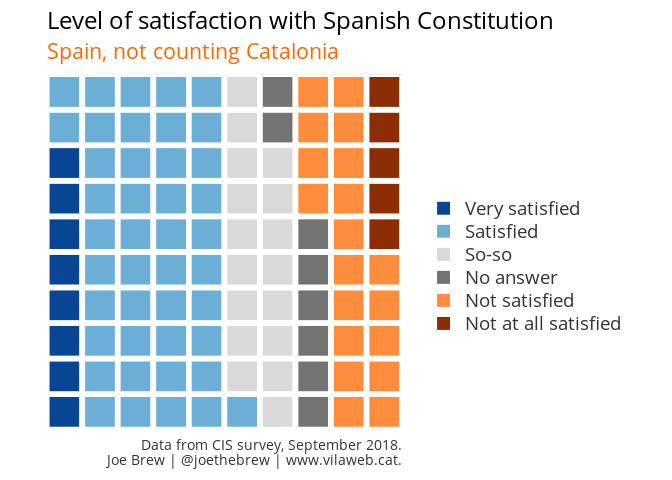

Given this high degree of satisfaction, serious reforms are unlikely in the near future.

## Dissatisfaction with the Constitution in Catalonia

If we look just at Catalonia, the opposite pattern emerges. Only 1.75% are "very satisfied" with the Constitution, less than one fourth the rate of high satisfaction in the rest of Spain. And the sum of the "very satisfied" and "satisfied" group rises to only 22.55%.

The percentage of Catalans who are not satisified with the Constitution is over twice that: 52.1%. 24.3% of Catalans are "not satisfied", and 27.8% are not at all satisfied.

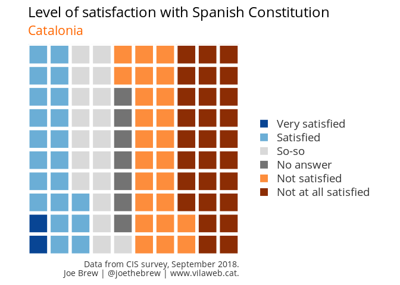

## Variation in satisfaction with the Constitution in other Autonomous Communities

Of the 17 CCAAs, Catalonia has the highest dissatisfaction rate, exceeding 50%. But there are two other CCAAs where dissatisfaction is greater than satisfaction: in the Basque Country, 41.6% are dissatisfied with the Constitution whereas only 32.9% are satisfied; and in Navarra, 39% are dissatisfied with the Constitution whereas 31.7% are satisfied.

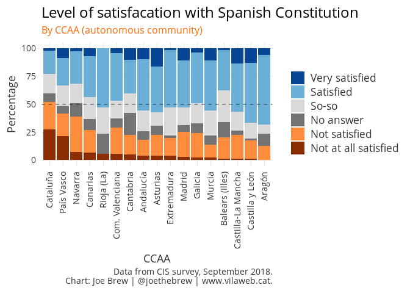

## Broad opposition to self-determination in Spain

In a national survey in October 2018, Spaniards were given 5 choices about their preferences for territorial organization: (i) a centralized state with no autonomy for the regions, (ii) a state with less autonomy than the current status quo, (iii) status quo, (iv) greater autonomy for the regions, (v) the possibility for regions to become independent.

A majority of non-Catalan Spaniards (76.4%) want to either keep the status quo (41.6%) or *decrease* the amount of autonomy given to the regions (34.8). A full 22.5% want a centralized state with no autonomy for the regions. Only 5% are in favor of granting self-determination to regions.

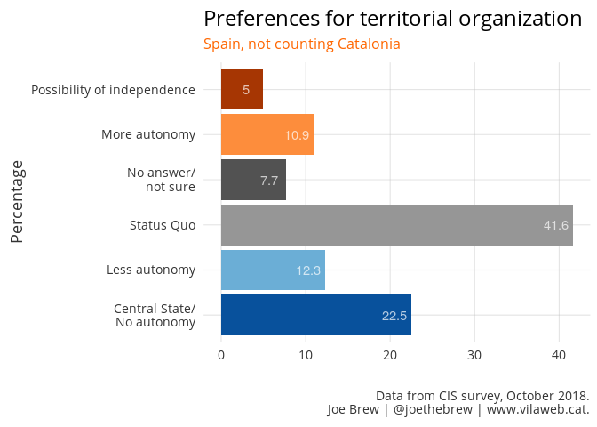

## The consensus for self-determination in Catalonia

Only 19.1% of Catalans believe that Catalonia does not have a right to a self-determination referendum, whereas 68.4% believe that it does. Removing those who do not answer the question, 78.2% of Catalans believe that Catalonia has a right to a self-determination referendum.

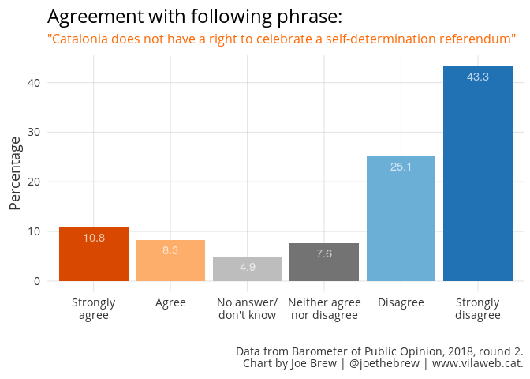

# Qualitative reflection

## "Social fracture" and its causes

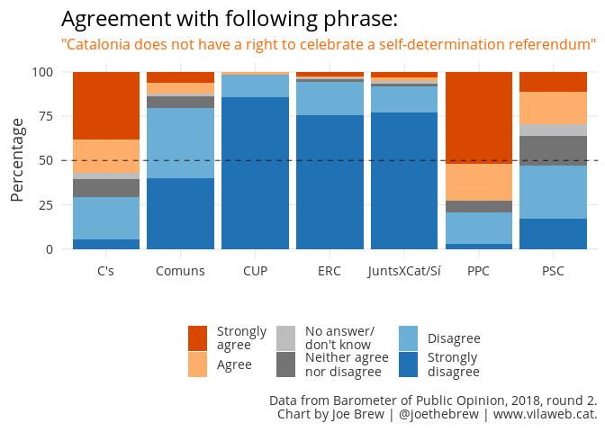

On the other hand, in a hypothetical referendum on the Spanish Constitution, only 17.4% of Catalans say that they would vote "yes". Even if we remove the 25.6% which don't know or don't answer, the percentage who would vote "yes" would be only 23.4% ("no" would be 76.6%).

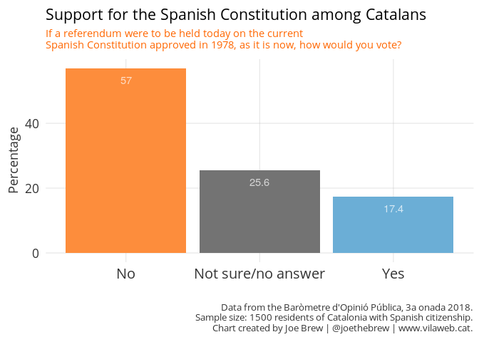

Perhaps the "social fracture" is not due to the desire for self-determination, but due to a Constitution which is supported by fewer than 1 in 5 Catalans?

## Conclusion: the broad consensus

Pedro Sánchez [recently said](http://www.lamoncloa.gob.es/serviciosdeprensa/boln/Paginas/2018/boln20181223.aspx) that the Catalan crisis "is going to last for years" since a solution will require a "broad social majority which does not exist right now in Catalonia".

But the data are clear. Catalans already share a broad consensus: more than 3/4 are in favor of exercising the right to self-determination, and more than 3/4 are opposed to the Spanish Constitution which prevents them from exercising that right.

It is a strange that in many political sectors, the 78% consensus in favor of a self-determination referendum is considered "not enough", but the 23% consensus in favor of the Constitution is considered sufficient for the continued governance of Catalonia. It is also strange that mainstream Spanish political parties and politicians continue to treat the broad desire among Catalans for self-determination as a question of criminal law, rather than politics. As long as a broad majority of Catalans favor self-determination, they will continue to elect politicians who pursue it (within or outside of Spanish law). And as long as a broad majority of Catalans are opposed to the Spanish Constitution, they will continue to elect politicians who create laws outside of it.

A political solution to the Catalan crisis requires recognition of the following three truths:

1. A broad consensus in favor of self-determination already exists among Catalans.
2. The root cause of the current crisis is not a disagreement among Catalans, but rather the prohibition by Spain of Catalonia acting on that broad consensus.
3. Governing a territory in which fewer than one quarter of the inhabitants approve of the "rules of the game" (the Constitution) is simply unsustainable, and will likely lead to further "illegal" policies voted and approved by Catalan leaders.

Mr. Sánchez is correct that the crisis will "last for years" if Spain is politically incapable of accepting an independence referendum in Catalonia. But a prolonged crisis is neither necessary nor inevitable. The consensus for the solution already exists among Catalans. Pretending that this consensus does not exist, or describing the political crisis as a "conflict between Catalans" reflects ignorance of reality... or a desire to twist it.

# Catalan language plots

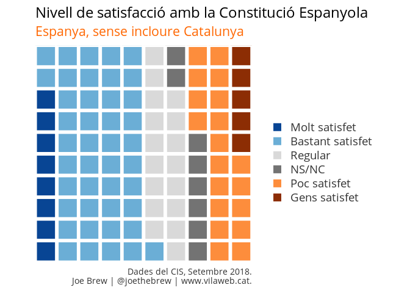

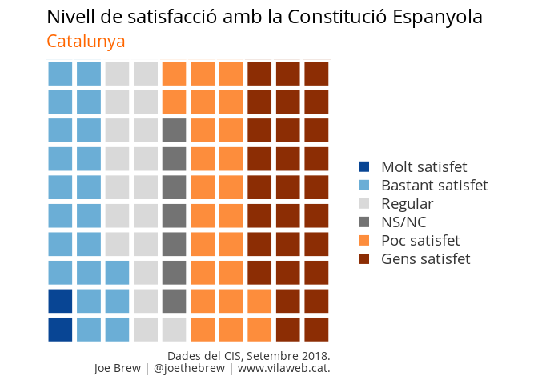

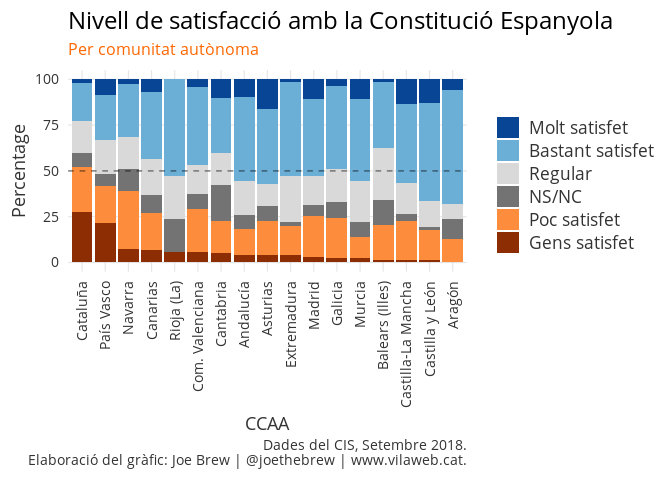

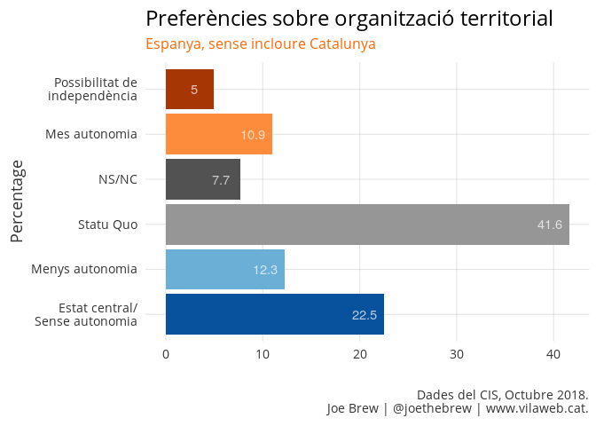

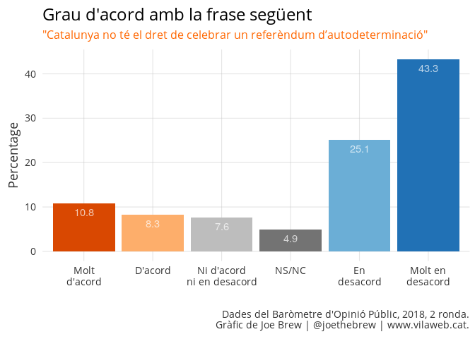

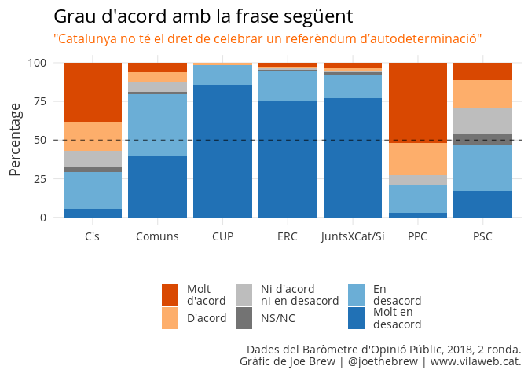

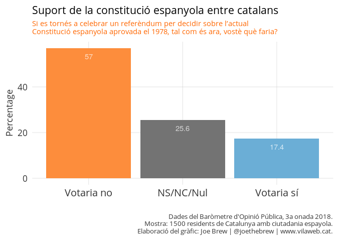